# Co-phylogenetic analyses

### Background

Zoonoses, pathogens transmitted between humans and animal taxa, are a rising threat to public health and wildlife conservation. With the increase in emergence of zoonotic infectious diseases, research to predict and survey potentially zoonotic host-pathogen interactions is critical (Cleavland et al. 2001; Taylor et al. 2001; Han et al. 2016; Olival et al. 2017). Recent work indicates that hosts infected by phylogenetically diverse pathogens are at a higher risk for disease spillover (Olival et al. 2017). Additionally, host shifts are more likely to occur between closely related hosts (Davies & Pederson 2008; Ramsden et al. 2009; Cooper et al. 2012; Huang et al. 2013; Longdon et al. 2014), suggesting that close relatives of humans infected by phylogenetically diverse pathogens are most likely to cause a spillover event. Understanding which ecological and evolutionary components of host-pathogen interactions lead to spillover events remains challenging but necessary to more accurately surrey potential emerging infectious diseases.

Given an observed pattern of host-parasite associations and phylogenies for the host and parasite species, we can test four possible explanations for the observed pattern. The pattern could be random with respect to both phylogenies, which might suggest that host-parasite interactions are driven more by biotic or abiotic factors than by evolution. At the opposite end of the spectrum, it could be that the pattern is driven by coevolution between the hosts and parasites, so that closely related hosts tend to be infected by closely related parasites. (Discussion material: the TREE paper we read from Soren Nylin recently that was arguing against cospeciation being an important force). There are also two intermediate perspectives. It is possible that the pattern is largely driven by host or parasite evolution. In the former case, closely related hosts are infected by similar parasites, irrespective of the relatedness of those parasites. In the latter case, closely related parasites infect similar hosts, irrespective of the relatedness of those hosts. Determining which of these explanations provides the best fit with data can help us to identify zoonotic disease threats. For example, if host-parasite associations are driven by coevolution, then the most likely parasites to spill into humans will be those that both infect our close relatives and are closely related to parasites already known to infect us. However, if host evolution plays the dominant role, then we need to focus our attention on all of the parasites of our close relatives, regardless of whether they are similar to parasites that already infect us. This may be a relatively straightforward task. On the other hand, if parasite evolution plays the dominant role, the task is more difficult because it would require us to identify the close relatives of our parasites, whatever may be their current hosts.

### Methods

The data for this analysis is comprised of three things: (1) an incidence matrix of host-parasite interactions; (2) a host phylogeny; (3) a parasite phylogeny. To determine whether there are any general patterns in the effect of host and parasite (co)evolution on host-parasite interactions, we work with two different datasets of host-parasite interaction: the first comes from the Global Mammal Parasite Database, and the second from a database of museum-verified Nearctic host-parasite associations. Additionally, we analyze these patterns using only the data on Primate-parasite associations in the GMPD. With these data, we can carry out several different co-phylogenetic analyses using different methods that have been proposed in the literature.

```r
library(MCMCglmm)
library(gdata)
```

```r
library(igraph)
library(phytools)
library(tidyverse)
library(parallel)

###############################
##      Load the trees       ##
###############################
gmpd_mam_tree <- read.tree("mammal_tree_clean.tre")
gmpd_para_tree <- read.tree("helminth_tree_clean.tre")

###############################
##  Format the GMPD Data     ##
###############################
data <- read.csv("GMPD_clean.csv")

## create a new data.frame with all possible host-parasite combinations
expand.grid(Host.species=(data$HostCorrectedName %>% unique),
            Parasite.species=(data$ParasiteCorrectedName %>% unique)) -> ndata

## ncount = the number of times that each association occurs in data
## presence = incidence data (0/1 if the association occurs or not)
## nhosts.sampled = the number of times each host occurs in the GMPD
## nparas.sampled = the number of times each parasite occurs in the GMPD
mutate(ndata,
       ncount=left_join(ndata, data %>% count(HostCorrectedName,ParasiteCorrectedName),
                        by=c("Host.species"="HostCorrectedName","Parasite.species"="ParasiteCorrectedName"))$n,
       presence=ifelse(is.na(ncount),0,1),
       nhosts.sampled=left_join(ndata, data %>% count(HostCorrectedName),
                                by=c("Host.species"="HostCorrectedName"))$n,
       nparas.sampled=left_join(ndata, data %>% count(ParasiteCorrectedName),
                                by=c("Parasite.species"="ParasiteCorrectedName"))$n) -> gmpd_ndata

##################################
##      Primate-only data       ##
##################################
pdata <- subset(data, HostOrder=="Primates")

## prune the phylogenies to include only this data
primate_tree <- keep.tip(gmpd_mam_tree, gsub(" ","_",unique(pdata$HostCorrectedName)))
primate_para_tree <- keep.tip(gmpd_para_tree, gsub(" ","_",unique(pdata$ParasiteCorrectedName)))

## create a new data.frame with all possible host-parasite combinations
expand.grid(Host.species=(pdata$HostCorrectedName %>% unique),
            Parasite.species=(pdata$ParasiteCorrectedName %>% unique)) -> primate_ndata
mutate(primate_ndata,
       ncount=left_join(primate_ndata, pdata %>% count(HostCorrectedName,ParasiteCorrectedName),
                        by=c("Host.species"="HostCorrectedName","Parasite.species"="ParasiteCorrectedName"))$n,
       presence=ifelse(is.na(ncount),0,1),
       nhosts.sampled=left_join(primate_ndata, pdata %>% count(HostCorrectedName),
                                by=c("Host.species"="HostCorrectedName"))$n,
       nparas.sampled=left_join(primate_ndata, pdata %>% count(ParasiteCorrectedName),
                                by=c("Parasite.species"="ParasiteCorrectedName"))$n) -> primate_ndata
primate_ndata$Host.species <- as.factor(as.character(primate_ndata$Host.species))
primate_ndata$Parasite.species <- as.factor(as.character(primate_ndata$Parasite.species))

##############################
##      Nearctic data       ##
##############################

## Load the trees
nearctic_mam_tree <- read.tree("nearctic_mammal_tree_clean.tre")
nearctic_para_tree <- read.tree("nearctic_helminth_tree_clean.tre")
## Load the data
nearctic_data <- read.csv("nearctic_data_clean.csv")

expand.grid(Host.species=(nearctic_data$Host %>% unique),
            Parasite.species=(nearctic_data$Parasite %>% unique)) -> nearctic_ndata
mutate(nearctic_ndata,
       ncount=left_join(nearctic_ndata, nearctic_data %>% count(Host,Parasite),
                        by=c("Host.species"="Host","Parasite.species"="Parasite"))$n,
       presence=ifelse(is.na(ncount),0,1),
       nhosts.sampled=left_join(nearctic_ndata, nearctic_data %>% count(Host),
                                by=c("Host.species"="Host"))$n,
       nparas.sampled=left_join(nearctic_ndata, nearctic_data %>% count(Parasite),
                                by=c("Parasite.species"="Parasite"))$n) -> nearctic_ndata
```

The first method is ParaFitGlobal (Legendre et al. 2002), which evaluates the evidence for coevolution between parasites and hosts. This method works by testing for congruence between host and parasite phylogenetic trees, that is, it tests whether hosts and their parasites have equivalent positions in their respective trees. Perfect congruence would signal tight codiversification of specialist parasites with their hosts, whereas no congruence would signal that host-parasite associations are formed randomly with respect to the evolutionary history of each species. As such, the null hypothesis that the method is testing is that the evolution of hosts and parasites is independent. This method was one of the first developed that could account for the fact that many parasites can infect more than one host, and that hosts are often infected by many parasites.

The computes a so-called “fourth corner” statistic (Legendre) based on the product of matrices describing (A) the presence/absence of each host-parasite association; (B) the parasite phylogenetic tree; and (C) the host phylogenetic tree. To determine whether this statistic has a value that is different than what you would expect via chance, the presence/absence data is randomly permuted in three ways. Legendre et al. proposed a permutation such that each parasite infects the same number of hosts, but the identity of those hosts is randomly determined. However, an alternative would be a permutation such that each host is infected by the same number of parasites, but the identify of those parasites is randomly determined. Hommola et al. proposed a third possibility, where only the total number of host-parasite associations is preserved, and those associations are randomly determined. Under all perturbations, the test statistic is computed to produce null distributions of the test statistic that the true value can be compared against. As pointed out by Hadfield et al. (2014), comparing the value of the test statistic against the null distributions generated by different types of permutation provides slightly different information. In particular, the first permutation tests for host-parasite coevolution, for host evolutionary interactions (which occur if related hosts are infected by similar parasites, irrespective of the parasite phylogeny), for parasite evolutionary interactions (which occur if related parasites infect similar hosts, irrespective of the host phylogeny), and for phylogenetic signal in the parasite species richness infecting hosts (because the permutation alters the number of parasites infecting each host). The second permutation tests for coevolution, host and parasite evolutionary interactions, and for phylogenetic signal in the host range of parasites (because the permutation alters the number of hosts each parasite infects). The third permutation tests for coevolution, host and parasite evolutionary interactions, and for phylogenetic signal in both parasite species richness and host range.

(Sidenote: Legendre et al. 2002 also provide a method for testing whether there are host-parasite associations that are particularly important to the overall coevolutionary pattern. I haven’t used this method because I wasn’t sure why I would, but it could be done pretty easily.)

```r
if(!file.exists("legendre_results.RDS")) {
  legendre_results <- array(NA, dim=c(3,5))
  colnames(legendre_results) <- c("dataset","value", "L1-pval", "L2-pval", "H-pval")
  for (mod in 1:3) {
    if (mod==1) {
      dataset <- "GMPD"
      mam_tree <- gmpd_mam_tree
      para_tree <- gmpd_para_tree
      ndata <- gmpd_ndata
    } else if (mod==2) {
      dataset <- "Primates"
      mam_tree <- primate_tree
      para_tree <- primate_para_tree
      ndata <- primate_ndata
    } else {
      dataset <- "Nearctic"
      mam_tree <- nearctic_mam_tree
      para_tree <- nearctic_para_tree
      ndata <- nearctic_ndata
    }
    # matrices for host and parasite based on the branch lengths in the phylogenetic tree
    # (Note that differences in tree depth do not matter because of the use of corr=T)
    ht<-vcv(mam_tree, corr=T)
    pt<-vcv(para_tree, corr=T)

    # incidence data
    Y<-table(ndata$Host.species, ndata$Parasite.species, ndata$presence)[,,2]>0
    ## change names to match the phylogeny
    rownames(Y) <- gsub(" ", "_", rownames(Y))
    colnames(Y) <- gsub(" ", "_", colnames(Y))

    ## reorder A matrices so match row/columns of Y
    hi<-match(rownames(Y), rownames(ht))
    pi<-match(colnames(Y), rownames(pt))
    ht<-ht[hi,hi]
    pt<-pt[pi,pi]

    ## get principal coordinates of the phylogenetic distance matrix (for the Legendre approach)
    htp<-pcoa(1-ht)$vectors
    ptp<-pcoa(1-pt)$vectors

    ## D matrices (see Appendix) for Legendre and Ives methods
    lD<-t(htp)%*%Y%*%ptp

    ## Legendre metric
    cl<-sum(diag(t(lD)%*%lD))

    ## Bootstrap result storage
    boot.1 <- 1:1000
    boot.2 <- 1:1000
    boot.3 <- 1:1000

    ##################
    ## Permutations ##
    ##################
    ## Compute the Legendre metric for randomly permuted
    ## incidence data.
    for(j in 1:1000){
      print(j)

      Y2<-apply(Y, 2, sample)                     # Legendre permtations
      lD<-t(htp)%*%Y2%*%ptp                       # Legendre D matrix
      boot.1[j]<-sum(diag(t(lD)%*%lD))              # Legendre metric (ParafitGlobal)

      Y2 <- apply(Y, 1, sample)
      lD<-t(ptp)%*%Y2%*%htp                       # Legendre D matrix
      boot.2[j]<-sum(diag(t(lD)%*%lD))              # Legendre metric (ParafitGlobal)

      Y2<-Y[sample(1:nrow(Y)),sample(1:ncol(Y))]  # Hommola sampling
      lD<-t(htp)%*%Y2%*%ptp
      boot.3[j]<-sum(diag(t(lD)%*%lD))
    }
    legendre_results[mod,] <- c(dataset, cl, sum(cl < boot.1)/1000, sum(cl < boot.2)/1000, sum(cl < boot.3)/1000)
  }
  saveRDS(legendre_results, file="legendre_results.RDS")
}
```

The second method is that of Hommola et al. (2009), which tests for a correlation between shared branch lengths. More specifically, the method looks at pairs of host-parasite associations and calculates the phylogenetic distance between the hosts in the pair and between the parasites in the pair: the host distance will be zero for pairs representing two parasites infecting the same host; similarly, the parasite distance will be zero for pairs representing a parasite infecting two hosts. After computing these branch lengths for all pairs, the method then estimates the correlation between the host distances and the parasite distances over all host-parasite association pairs. A high correlation means that, when two hosts are far apart on the tree, the parasites that infect them also tend to be far apart; similarly, when hosts are closely related, their parasites tend to be closely related as well. A low correlation would mean that there is no relationship between the distance between hosts and between parasites. We compute this correlation in our three datasets, and then compare the observed correlation against randomly permuted data, using the same set of permutations described above. Like the method of Legendre et al., this test can provide evidence for phylogenies affecting host-parasite associations.

```r
if(!file.exists("Hommola_results.RDS")) {
  ## make sure you have a compiled Hommola.so available in this directory before running hommola()
  source("Hommola.R")
  hommola_results <- array(NA, dim=c(3,5))
  colnames(hommola_results) <- c("dataset","value", "L1-pval", "L2-pval", "H-pval")
  for (mod in 1:3) {
    if (mod==1) {
      dataset <- "GMPD"
      mam_tree <- gmpd_mam_tree
      para_tree <- gmpd_para_tree
      ndata <- gmpd_ndata
    } else if (mod==2) {
      dataset <- "Primates"
      mam_tree <- primate_tree
      para_tree <- primate_para_tree
      ndata <- primate_ndata
    } else {
      dataset <- "Nearctic"
      mam_tree <- nearctic_mam_tree
      para_tree <- nearctic_para_tree
      ndata <- nearctic_ndata
    }

    # matrices for host and parasite based on the branch lengths in the phylogenetic tree
    # (Note that differences in tree depth do not matter because of the use of corr=T)
    ht<-vcv(mam_tree, corr=T)
    pt<-vcv(para_tree, corr=T)

    # incidence data
    Y<-table(ndata$Host.species, ndata$Parasite.species, ndata$presence)[,,2]>0
    ## change names to match the phylogeny
    rownames(Y) <- gsub(" ", "_", rownames(Y))
    colnames(Y) <- gsub(" ", "_", colnames(Y))

    ## Metrics of Legendre, Ives & Godfray, and Hommola (see Appendix of Hadfield et al. 2014)
    ch<-hommola(Y, ht,pt)

    boot.1 <-1:1000
    boot.2 <-1:1000
    boot.3 <-1:1000

    ##################
    ## Permutations ##
    ##################
    for(j in 1:1000){

      Y2<-apply(Y, 2, sample)                     # Legendre permtations
      boot.1[j]<-hommola(Y2, ht,pt)                 # Hommola metric

      Y2<-apply(Y, 1, sample)
      boot.2[j]<-hommola(Y2, pt, ht)

      Y2<-Y[sample(1:nrow(Y)),sample(1:ncol(Y))]  # Hommola sampling
      boot.3[j]<-hommola(Y2, ht,pt)
    }
    hommola_results[mod,] <- c(dataset, ch, sum(ch < boot.1)/1000, sum(ch < boot.2)/1000, sum(ch < boot.3)/1000)
  }
  saveRDS(hommola_results, file="Hommola_results.RDS")
}
```

The third and fourth methods, in contrast to the first two, provide additional information that can help us to determine whether the pattern of host-parasite association is more strongly structured by host evolutionary history, parasite evolutionary history, or coevolution. The third method is that of Ives and Godfray (2006); it essentially transforms the branch lengths of the host and parasite phylogenies to maximize the fit of the evolutionary model to the observed host-parasite association data. This is in contrast to the related method of Legendre et al., which holds the branch lengths constant. Statistically speaking, the Legendre et al. method assumes that the covariance between species is determined by the branch lengths under a Brownian motion evolutionary process. In contrast, the Ives and Godfray method adjusts the covariance between any two tips in either tree to maximize the fit of the evolutionary model. This covariance is specified by an Ornstein-Uhlenbeck process with a parameter $d$ that determines the strength of the phylogenetic signal; this essentially transforming the branch lengths (Blomberg et al. 2003). The Ornstein-Uhlenbeck model is often described as a model for stabilizing selection: a deterministic tendency towards an “optimal” value for a trait evolving along a phylogeny (Hansen 1997). If $d=0$, there is no phylogenetic covariance between tips, which can be descrbied as a star phylogeny, whereas $d=1$ implies no selection and a covariance that is described by Brownian motion. A value of $0 < d< 1$ implies some amount of stabilizing selection, and $d > 1$ suggests disruptive selection. Since there are two phylogenies, the method assumes that there is some value, $d_h$ that best describes the covariance between host species, and a separate parameter, $d_p$, that describes the covariance between parasite species. The method estimates the values of $d_h$ and $d_p$ that minimize the mean square error between the model-predicted host-parasite associations and the observed host-parasite associations. Comparing the values of $d_h$ and $d_p$ give a sense of how much phylogenetic signal is due to the host versus the parasite.

We use the method in full for the Nearctic and Primate datasets, first fitting simplified versions of the model that either fix $d_h=d_p=0$ (star phylogeny) or $d_h=d_p=1$ (Brownian motion), then fitting the full model that fits $d_h$ and $d_p$ to the data. Unfortunately, the GMPD dataset is too large for the full method to work: both the code provided in the supplementary material of Ives and Godfray (2006) and in the R package picante (ref) that implements the method generate matrices that are so large that they consume all available computer memory.

However, Hadfield et al. (2014) provide code for computing a statistic that is proportional to mean square error under the assumption that $d_h=d_p=1$ (Brownian motion evolution); their code does not generate large matrices, and is thus possible to apply all three datasets. This statistic is very similar to that of Legendre et al. (2002). It is also possible to compute the mean square error under the assumption that $d_h=d_p=0$ (star phylogeny) for all three models. We therefore compute these statistics for all three datasets, and use the same set of permutations described above to evaluate whether these two statistics are different from a null distribution based on randomly permuted host-parasite assocations. This provides an alternative metric to evaluate the evidence for phylogenetic signal in the pattern of host-parasite association.

```r
## Compute the full model of Ives & Godfray for the Nearctic and Primate datasets
ht<-vcv(nearctic_mam_tree, corr=T)
pt<-vcv(nearctic_para_tree, corr=T)
Y<-table(nearctic_ndata$Host.species, nearctic_ndata$Parasite.species, nearctic_ndata$presence)[,,2]>0
## change names to match the phylogeny
rownames(Y) <- gsub(" ", "_", rownames(Y))
colnames(Y) <- gsub(" ", "_", colnames(Y))

## reorder A matrices so match row/columns of Y
hi<-match(rownames(Y), rownames(ht))
pi<-match(colnames(Y), rownames(pt))
ht<-ht[hi,hi]
pt<-pt[pi,pi]

source("pblm.R") ## modified version of the code in the package 'picante'
o <- pblm(assocs=Y, tree1=ht, tree2=pt, maxit=1000)
saveRDS(o, file="IvesGodfray_full_nearctic.RDS")

## Generate new datasets using the best-fitting model to derive bootstrap CIs for the d1, d2 parameters
d1 <- o$signal.strength[1,2]
d2 <- o$signal.strength[2,2]
A<-as.matrix(as.vector(as.matrix(Y)))
nassocs<-length(A)
nspp1<-dim(Y)[1]
nspp2<-dim(Y)[2]
U<-rep(1,length(A))

initV1<-as.matrix(ht)
initV2<-as.matrix(pt)

# tau = tau_i + tau_j where tau_i equals the node to tip distance
tau1<-matrix(diag(initV1),nspp1,nspp1) + matrix(diag(initV1),nspp1,nspp1)-2*initV1
tau2<-matrix(diag(initV2),nspp2,nspp2) + matrix(diag(initV2),nspp2,nspp2)-2*initV2

V1<-(d1^tau1)*(1-d1^(2*initV1))/(1-d1^2)
V2<-(d2^tau2)*(1-d2^(2*initV2))/(1-d2^2)
V1<-V1/det(V1)^(1/nspp1)   # model of coevolution
V2<-V2/det(V2)^(1/nspp2)
V <- kronecker(V2,V1)
invV<-kronecker(chol2inv(chol(V2)),chol2inv(chol(V1)))

aFull<-solve((t(U)%*%invV%*%U),((t(U)%*%invV%*%A)))   #NOTE: Ives in his Matlab code uses a Left matrix division symbol (\)

Vtrue<-V
Atrue<-A
atrue<-aFull
dtrue<-c(d1,d2)
ehold<-eigen(Vtrue,symmetric=TRUE)
L<-ehold$vectors[,nassocs:1]    #A or L
G<-sort(ehold$values)      #D
iG<-diag(G^-.5)    #iD

# Construct Y = TT*A so that
# E{(Y-b)*(Y-b)'} = E{(TT*A-b)*(TT*A-b)'}
#                 = T*V*T'
#                 = I
TT<-iG%*%t(L)
Y<-TT%*%Atrue
Z<-TT%*%U

res<-(Y-Z%*%atrue)  # residuals in orthogonalized space
invT <- qr.solve(TT)

set.seed(1243897)
Aboot <- vector(mode='list', length=100)
for (i in 1:length(Aboot)) {
  randindex<-sample(1:nassocs,replace=TRUE) # vector of random indices
  #randindex=1:nassocs                  # retain order
  YY<-Z%*%atrue+res[randindex]  # create new values of Y with random residuals
  Aboot[[i]]<-invT%*%YY # back-transformed data
}
saveRDS(Aboot, "Nearctic_bootstrap_datasets.RDS")

#### Execute the bootstrap
o <- readRDS("IvesGodfray_full_nearctic.RDS")
d1 <- o$signal.strength[1,2]
d2 <- o$signal.strength[2,2]

Aboot <- readRDS("Nearctic_bootstrap_datasets.RDS")
ht<-vcv(nearctic_mam_tree, corr=T)
pt<-vcv(nearctic_para_tree, corr=T)
Y<-table(nearctic_ndata$Host.species, nearctic_ndata$Parasite.species, nearctic_ndata$presence)[,,2]>0
## change names to match the phylogeny
rownames(Y) <- gsub(" ", "_", rownames(Y))
colnames(Y) <- gsub(" ", "_", colnames(Y))

## reorder A matrices so match row/columns of Y
hi<-match(rownames(Y), rownames(ht))
pi<-match(colnames(Y), rownames(pt))
ht<-ht[hi,hi]
pt<-pt[pi,pi]


source("pblm_bootstrap.R")
mclapply(Aboot,
         function(A) pblm_boot(A, ht, pt, d1, d2),
         mc.cores=2) -> ob
saveRDS(ob, file="IvesGodfray_full_nearctic_bootstraps.RDS")

## Compute the full model of Ives & Godfray for the Primate dataset
ht<-vcv(primate_tree, corr=T)
pt<-vcv(primate_para_tree, corr=T)
Y<-table(primate_ndata$Host.species, primate_ndata$Parasite.species, primate_ndata$presence)[,,2]>0
## change names to match the phylogeny
rownames(Y) <- gsub(" ", "_", rownames(Y))
colnames(Y) <- gsub(" ", "_", colnames(Y))

## reorder A matrices so match row/columns of Y
hi<-match(rownames(Y), rownames(ht))
pi<-match(colnames(Y), rownames(pt))
ht<-ht[hi,hi]
pt<-pt[pi,pi]

o <- pblm(assocs=Y, tree1=ht, tree2=pt, maxit=1000)
saveRDS(o, file="IvesGodfray_full_primate.RDS")

## Generate new datasets using the best-fitting model to derive bootstrap CIs for the d1, d2 parameters
d1 <- o$signal.strength[1,2]
d2 <- o$signal.strength[2,2]
A<-as.matrix(as.vector(as.matrix(Y)))
nassocs<-length(A)
nspp1<-dim(Y)[1]
nspp2<-dim(Y)[2]
U<-rep(1,length(A))

initV1<-as.matrix(ht)
initV2<-as.matrix(pt)

# tau = tau_i + tau_j where tau_i equals the node to tip distance
tau1<-matrix(diag(initV1),nspp1,nspp1) + matrix(diag(initV1),nspp1,nspp1)-2*initV1
tau2<-matrix(diag(initV2),nspp2,nspp2) + matrix(diag(initV2),nspp2,nspp2)-2*initV2

V1<-(d1^tau1)*(1-d1^(2*initV1))/(1-d1^2)
V2<-(d2^tau2)*(1-d2^(2*initV2))/(1-d2^2)
V1<-V1/det(V1)^(1/nspp1)   # model of coevolution
V2<-V2/det(V2)^(1/nspp2)
V<-kronecker(V2,V1)
invV<-chol2inv(chol(V))

aFull<-solve((t(U)%*%invV%*%U),((t(U)%*%invV%*%A)))   #NOTE: Ives in his Matlab code uses a Left matrix division symbol (\)

Vtrue<-V
Atrue<-A
atrue<-aFull
dtrue<-c(d1,d2)
ehold<-eigen(Vtrue,symmetric=TRUE)
L<-ehold$vectors[,nassocs:1]    #A or L
G<-sort(ehold$values)      #D
iG<-diag(G^-.5)    #iD

# Construct Y = TT*A so that
# E{(Y-b)*(Y-b)'} = E{(TT*A-b)*(TT*A-b)'}
#                 = T*V*T'
#                 = I
TT<-iG%*%t(L)
Y<-TT%*%Atrue
Z<-TT%*%U

res<-(Y-Z%*%atrue)  # residuals in orthogonalized space
invT <- qr.solve(TT)

set.seed(1243897)
Aboot <- vector(mode='list', length=100)
for (i in 1:length(Aboot)) {
  randindex<-sample(1:nassocs,replace=TRUE) # vector of random indices
  #randindex=1:nassocs                  # retain order
  YY<-Z%*%atrue+res[randindex]  # create new values of Y with random residuals
  Aboot[[i]]<-invT%*%YY # back-transformed data
}
saveRDS(Aboot, "Primate_bootstrap_datasets.RDS")

source("pblm_bootstrap.R")

mclapply(Aboot,
         function(A) pblm_boot(A, ht, pt, d1, d2),
         mc.cores=4) -> ob
saveRDS(ob, file="IvesGodfray_full_primate_bootstraps.RDS")


## Use the simplified version of Hadfield et al. 2014
if(!file.exists("IvesGodfray_simplified_results.RDS")) {
  ives_results <- array(NA, dim=c(6,6))
  colnames(ives_results) <- c("dataset", "model", "value", "L1-pval", "L2-pval", "H-pval")
  for (mod in 1:3) {
    if (mod==1) {
      dataset <- "GMPD"
      mam_tree <- gmpd_mam_tree
      para_tree <- gmpd_para_tree
      ndata <- gmpd_ndata
    } else if (mod==2) {
      dataset <- "Primates"
      mam_tree <- primate_tree
      para_tree <- primate_para_tree
      ndata <- primate_ndata
    } else {
      dataset <- "Nearctic"
      mam_tree <- nearctic_mam_tree
      para_tree <- nearctic_para_tree
      ndata <- nearctic_ndata
    }

    # matrices for host and parasite based on the branch lengths in the phylogenetic tree
    # (Note that differences in tree depth do not matter because of the use of corr=T)
    ht<-vcv(mam_tree, corr=T)
    pt<-vcv(para_tree, corr=T)

    # incidence data
    Y<-table(ndata$Host.species, ndata$Parasite.species, ndata$presence)[,,2]>0
    ## change names to match the phylogeny
    rownames(Y) <- gsub(" ", "_", rownames(Y))
    colnames(Y) <- gsub(" ", "_", colnames(Y))

    ## reorder A matrices so match row/columns of Y
    hi<-match(rownames(Y), rownames(ht))
    pi<-match(colnames(Y), rownames(pt))
    ht<-ht[hi,hi]
    pt<-pt[pi,pi]

    ## get unnormalised eigenvectors of phylogenetic distance matrix
    hte<-t(t(eigen(solve(ht))$vectors)*sqrt(eigen(solve(ht))$values))
    pte<-t(t(eigen(solve(pt))$vectors)*sqrt(eigen(solve(pt))$values))

    ## D matrix (see Appendix of Hadfield et al. 2014) for Ives & Godfray methods
    iD<-t(hte)%*%(Y-mean(Y))%*%pte

    ## MSEb metric of Ives & Godfray under Brownian motion (see Appendix of Hadfield et al. 2014)
    MSEbrown <- sum(diag(t(iD)%*%iD))
    ## ASIDE: Verify/test whether this is the same as the MSEb metric calculated using the code in picante
    ## The following comes from the code in pblm.R
    ## Note that it is not the same, but Hadfield et al. 2014 note that ci should actually only be *proportional* to MSEb, not necessarily identical to it.
    # A<-as.matrix(as.vector(as.matrix(Y)))
    # U<-rep(1,length(A))
    # invV <- kronecker(chol2inv(chol(as.matrix(pt))),chol2inv(chol(as.matrix(ht))))
    # abase<-solve((t(U)%*%invV%*%U),((t(U)%*%invV%*%A)))
    # MSEBase<-(t(A-U%*%abase)%*%invV%*%(A-U%*%abase))/(length(A)-1)
    ## MSEstar metric of Ives & Godfray under a star phylogeny (see code for pblm.R)
    MSEstar<-cov(as.matrix(as.vector(Y-mean(Y)))) %>% as.numeric()

    brown.boot.1<-1:1000
    brown.boot.2<-1:1000
    brown.boot.3<-1:1000
    star.boot.1<-1:1000
    star.boot.2<-1:1000
    star.boot.3<-1:1000

    ##################
    ## Permutations ##
    ##################
    for(j in 1:1000){
      print(j)
      Y2<-apply(Y, 2, sample)                     # Legendre permtations
      iD<-t(hte)%*%(Y2-mean(Y2))%*%pte            # Ives D matrix
      brown.boot.1[j]<-sum(diag(t(iD)%*%iD))              # Ives metric (MSEb)
      star.boot.1[j] <-cov(as.matrix(as.vector(Y2-mean(Y2)))) %>% as.numeric() # Ives metric MSEstar

      Y2<-apply(Y, 1, sample)                     # Legendre permtations
      iD<-t(pte)%*%(Y2-mean(Y2))%*%hte            # Ives D matrix
      brown.boot.2[j]<-sum(diag(t(iD)%*%iD))              # Ives metric (MSEb)
      star.boot.2[j] <-cov(as.matrix(as.vector(Y2-mean(Y2)))) %>% as.numeric() # Ives metric MSEstar

      Y2<-Y[sample(1:nrow(Y)),sample(1:ncol(Y))]  # Hommola sampling
      iD<-t(hte)%*%(Y2-mean(Y2))%*%pte
      brown.boot.3[j]<-sum(diag(t(iD)%*%iD))
      star.boot.3[j] <-cov(as.matrix(as.vector(Y2-mean(Y2)))) %>% as.numeric() # Ives metric MSEstar

    }
    ives_results[2*mod-1,] <- c(dataset, "brown", MSEbrown, sum(MSEbrown > brown.boot.1)/1000, sum(MSEbrown > brown.boot.2)/1000, sum(MSEbrown > brown.boot.3)/1000)
    ives_results[2*mod,] <- c(dataset, "star", MSEstar, sum(MSEstar > star.boot.1)/1000, sum(MSEstar > star.boot.2)/1000, sum(MSEstar > star.boot.3)/1000)

  }
  saveRDS(ives_results, file="IvesGodfray_simplified_results.RDS")
}
```

The fourth method comes from Krasnov et al. (2012). It is essentially a two-part algorithm. First, it estimates the modularity of the network formed by host-parasite associations: in a host-parasite network with high modularity, one would find clusters of hosts and parasites that interact mainly with one another, and not with other clusters of hosts and parasites. Modules are computed using the cluster_walktrap function in the R package igraph (Pons and Latapy 2005). Second, it estimates whether there is strong phylogenetic signal between modularity and the host or parasite phylogeny: that is, it determines whether the hosts and parasites that belong to modules tend to be closely related. It does this by calculating the correlation between comembership in a module and phylogenetic distance, that is, it asks whether, across all hosts (and parasites), is the pairwise phylogenetic distance between hosts (or parasites) within a single module less than the pairwise phylogenetic distance between hosts in separate modules. If so, then there is evidence for phylogeny structuring host-parasite associations. Again, we use permutations of the host-parasite association data to determine whether the observed correlations between comembership and phylogenetic distance are different from what you would expect for randomly constructed host-parasite association networks.

```r
###################################################
## Run module on data (from Krasnov et al. 2012) ##
###################################################

if (!file.exists("Krasnov_results.RDS")) {
  krasnov_results <- array(NA, dim=c(3,9))
  colnames(krasnov_results) <- c("dataset", "host-corr", "L1-pval", "L2-pval", "H-pval", "parasite-corr", "L1-pval", "L2-pval", "H-pval")
  for (mod in 1:3) {
    if (mod==1) {
      dataset <- "GMPD"
      mam_tree <- gmpd_mam_tree
      para_tree <- gmpd_para_tree
      ndata <- gmpd_ndata
    } else if (mod==2) {
      dataset <- "Primates"
      mam_tree <- primate_tree
      para_tree <- primate_para_tree
      ndata <- primate_ndata
    } else {
      dataset <- "Nearctic"
      mam_tree <- nearctic_mam_tree
      para_tree <- nearctic_para_tree
      ndata <- nearctic_ndata
    }

    # A matrices for host and parasite
    ht<-vcv(mam_tree, corr=T)
    pt<-vcv(para_tree, corr=T)

    # incidence data
    Y<-table(ndata$Host.species, ndata$Parasite.species, ndata$presence)[,,2]>0
    ## change names to match the phylogeny
    rownames(Y) <- gsub(" ", "_", rownames(Y))
    colnames(Y) <- gsub(" ", "_", colnames(Y))

    hi<-match(rownames(Y), rownames(ht))
    pi<-match(colnames(Y), rownames(pt))

    # reorder A matrices so match row/columns of Y
    ht<-ht[hi,hi]
    pt<-pt[pi,pi]

    # assign species to modules
    G<-graph_from_incidence_matrix(Y) ## create a bipartite igraph graph from the incidence matrix
    MU<-cluster_walktrap(G) ## identify clusters
    MU<-membership(MU) ## determine which clusters each host and parasite belong to

    lth<-which(lower.tri(ht))

    # correlation between comembership and phylogenetic distance of hosts
    chk<-cor(outer(MU[1:length(hi)], MU[1:length(hi)], "==")[lth], c(1-ht)[lth])

    ltp<-lower.tri(pt)

    cpk<-cor(outer(MU[length(hi)+1:length(pi)], MU[length(hi)+1:length(pi)], "==")[ltp], c(1-pt)[ltp])
    # correlation between comembership and phylogenetic distance of parasites

    ## Bootstrapping
    # storing host & parasite membership/phylogenetic-distance correlations after the different permutations
    spk.1<-1:1000
    spk.2<-1:1000
    spk.3<-1:1000
    shk.1<-1:1000
    shk.2<-1:1000
    shk.3<-1:1000

    for(i in 1:1000){
      print(i)
      Y2<-apply(Y, 2, sample)                     # Legendre sampling
      G2<-graph.incidence(Y2)
      MU2<-walktrap.community(G2)
      MU2<-membership(MU2)
      shk.1[i]<-cor(outer(MU2[1:length(hi)], MU2[1:length(hi)], "==")[lth], c(1-ht)[lth])
      spk.1[i]<-cor(outer(MU2[length(hi)+1:length(pi)], MU2[length(hi)+1:length(pi)], "==")[ltp], c(1-pt)[ltp])

      Y2<-apply(Y, 1, sample)                     # Legendre sampling
      G2<-graph.incidence(Y2)
      MU2<-walktrap.community(G2)
      MU2<-membership(MU2)
      spk.2[i]<-cor(outer(MU2[1:length(pi)], MU2[1:length(pi)], "==")[ltp], c(1-pt)[ltp])
      shk.2[i]<-cor(outer(MU2[length(pi)+1:length(hi)], MU2[length(pi)+1:length(hi)], "==")[lth], c(1-ht)[lth])


      Y2<-Y[sample(1:nrow(Y)),sample(1:ncol(Y))]  # Hommola sampling
      G2<-graph.incidence(Y2)
      MU2<-walktrap.community(G2)
      MU2<-membership(MU2)
      shk.3[i]<-cor(outer(MU2[1:length(hi)], MU2[1:length(hi)], "==")[lth], c(1-ht)[lth])
      spk.3[i]<-cor(outer(MU2[length(hi)+1:length(pi)], MU2[length(hi)+1:length(pi)], "==")[ltp], c(1-pt)[ltp])
      #print(i)
    }
    krasnov_results[mod,] <- c(dataset,
                               chk, sum(chk>shk.1)/1000, sum(chk>shk.2)/1000, sum(chk>shk.3)/1000,
                               cpk, sum(cpk>spk.1)/1000, sum(cpk>spk.2)/1000, sum(cpk>spk.3)/1000)
  }
  saveRDS(krasnov_results, file="Krasnov_results.RDS")
}
```

Note for Jonathan: we also attempted to run the full method of Hadfield et al. (2014), which is an extension of the approach of Ives and Godfray that uses a Bayesian approach to estimate the contribution of many different terms to the covariance observed in the host-parasite association data. In particular, Hadfield et al. estimate (1) whether the number of parasites infecting each host is explained by host phylogeny (the host evolutionary effect); (2) whether host range of each parasite is explained by parasite phylogeny (the parasite evolutionary effect); (3) whether related hosts are infected by similar parasites (the host evolutionary interaction effect); (4) whether related parasites infect similar hosts (the parasite evolutionary interaction); and (5) whether related parasites infect related hosts (the coevolutionary interaction). We were able to obtain preliminary results from a shorter run (100,000 iterations), but that had not yet converged. Runs of the model take several weeks and during a longer run, my computer crashed (perhaps due to the run itself). It’s unclear to us whether it makes sense to stub in these results now, with the goal of having a more complete run to analyze by the time of revisions, or whether to just leave them out entirely.

### Results

##### Legendre method

Using the Legendre et al. (2002) method, we can see good evidence for coevolution, host and parasite evolutionary interactions, and for phylogenetic signal in parasite species richness and host range in all three datasets. The observed value of the test statistic (which is meaningless in and of itself) is more extreme than the values observed for almost all of the bootstrap permutations, using any method of permutation. Thus, we conclude that there appears to be strong evidence for phylogenetic signal in the pattern of host-parasite associations, though we are not really able to determine whether that is more due to the host, or more due to the parasite, using this method.

```r
res <- readRDS("legendre_results.RDS")
res
```

```
##      dataset    value              L1-pval L2-pval H-pval
## [1,] "GMPD"     "637.819049188227" "0"     "0"     "0"
## [2,] "Primates" "6.69776365341545" "0.004" "0"     "0.001"
## [3,] "Nearctic" "12.3106371966957" "0"     "0"     "0"
```

##### Hommola method

```r
res <- readRDS("hommola_results.RDS")
res
```

```
##      dataset    value                   L1-pval L2-pval H-pval
## [1,] "GMPD"     "0.000976480200552879"  "0.353" "0.365" "0.334"
## [2,] "Primates" "0.0623094454501342"    "0.001" "0.115" "0.071"
## [3,] "Nearctic" "-0.000468175281842404" "0.365" "0.383" "0.336"
```

##### Ives & Godfray method

```r
ig_method_nearctic <- readRDS("IvesGodfray_full_nearctic.RDS")
## MSE estimates for each each model fitted to the Nearctic dataset
ig_method_nearctic$MSE
```

```
##     MSETotal   MSEFull    MSEStar  MSEBase
## 1 0.05731509 0.0589009 0.05731509 30.49405
```

```r
ig_method_primate <- readRDS("IvesGodfray_full_primate.RDS")
## MSE estimates for each each model fitted to the Priamte dataset
ig_method_primate$MSE
```

```
##     MSETotal    MSEFull    MSEStar  MSEBase
## 1 0.05893056 0.05601232 0.05893056 1.921781
```

```r
nearctic_boots <- readRDS("IvesGodfray_full_nearctic_bootstraps.RDS")
primate_boots <- readRDS("IvesGodfray_full_primate_bootstraps.RDS")

signal_estimates <- array(NA, dim=c(2,3))
colnames(signal_estimates) <- c("dataset", "d_h", "d_p")
c("Nearctic",
  paste0(signif(ig_method_nearctic$signal.strength$estimate[1],3), " (",
         signif((lapply(nearctic_boots, function(b) b[[1]]) %>% unlist %>% sort)[3],3), ", ",
         signif((lapply(nearctic_boots, function(b) b[[1]]) %>% unlist %>% sort)[97],3),")"),
  paste0(signif(ig_method_nearctic$signal.strength$estimate[2],3), " (",
         signif((lapply(nearctic_boots, function(b) b[[2]]) %>% unlist %>% sort)[3],3), ", ",
         signif((lapply(nearctic_boots, function(b) b[[2]]) %>% unlist %>% sort)[97],3),")")) -> signal_estimates[1,]
c("Primates",
  paste0(signif(ig_method_primate$signal.strength$estimate[1],3), " (",
         signif((lapply(primate_boots, function(b) b[[1]]) %>% unlist %>% sort)[3],3), ", ",
         signif((lapply(primate_boots, function(b) b[[1]]) %>% unlist %>% sort)[97],3),")"),
  paste0(signif(ig_method_primate$signal.strength$estimate[2],3), " (",
         signif((lapply(primate_boots, function(b) b[[2]]) %>% unlist %>% sort)[3],3), ", ",
         signif((lapply(primate_boots, function(b) b[[2]]) %>% unlist %>% sort)[97],3),")")) -> signal_estimates[2,]
```

```r
res <- readRDS("IvesGodfray_simplified_results.RDS")
res
```

```
##      dataset    model   value                L1-pval L2-pval H-pval
## [1,] "GMPD"     "brown" "339667.560349322"   "0.009" "0.002" "0.361"
## [2,] "GMPD"     "star"  "0.019480127589224"  "0"     "0"     "0"
## [3,] "Primates" "brown" "3453.44944604846"   "0.006" "0"     "0.047"
## [4,] "Primates" "star"  "0.058930562184038"  "0"     "0"     "0"
## [5,] "Nearctic" "brown" "189337.530222331"   "0.016" "0.1"   "0.158"
## [6,] "Nearctic" "star"  "0.0573150916712507" "0"     "0"     "0"
```

##### Krasnov method

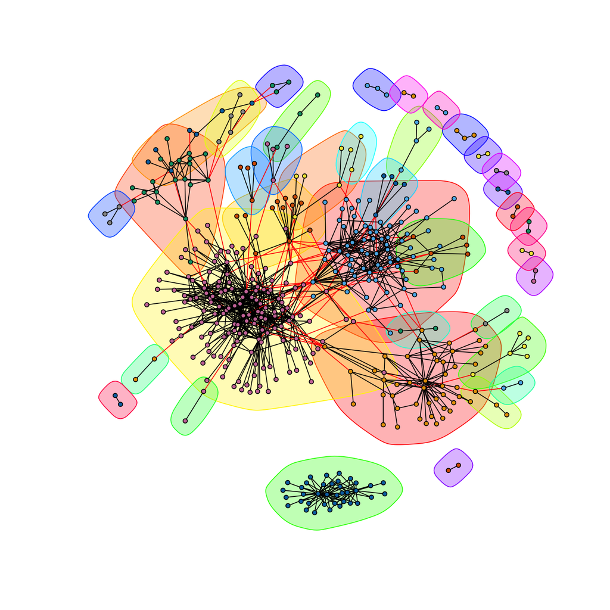

Host-parasite interaction network within the GMPD data, broken into 38 distinct modules.

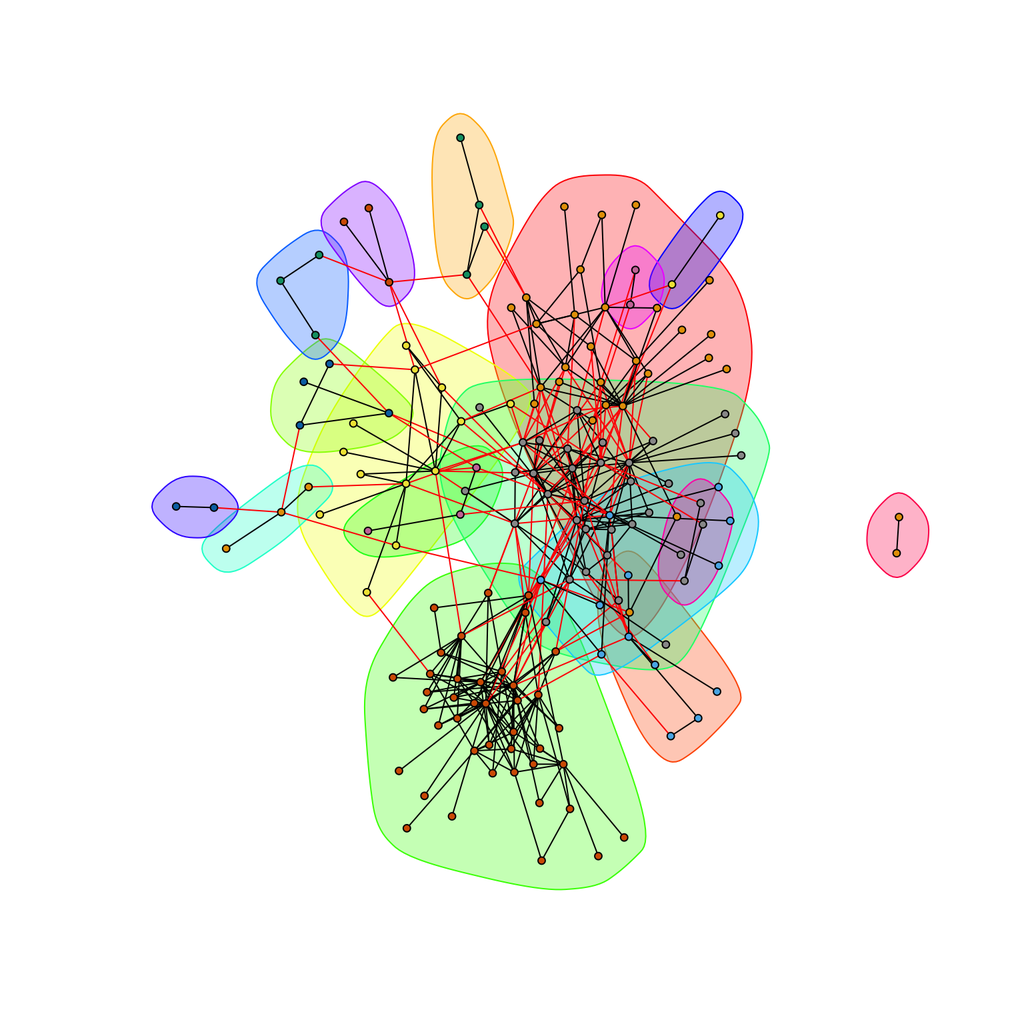

For the Primate dataset, we detected 20 distinct host-parasite clusters, with an the overall modularity score of 0.53. There are many very small modules, comprising a single host-parasite pair. The largest module (of 23 species), contains 18 species of Great Apes (both *Pan* species), lesser apes, and Old and New World monkeys.

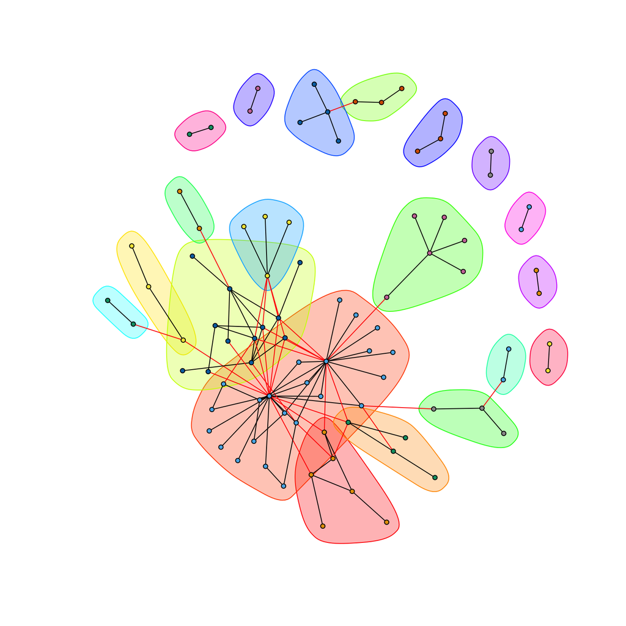

Host-parasite interaction network within the Primate dataset, broken into 20 distinct modules.

Looking across the datasets, there was always a very strong and significant negative correlation between comembership in a module and phylogenetic distance for hosts, indicating that more closely related hosts are more likely to end up in the same module. However, parasite relatedness was never significantly related to membership in a module.

```r
res <- readRDS("Krasnov_results.RDS")
res
```

```
##      dataset    host-corr            L1-pval L2-pval H-pval
## [1,] "GMPD"     "-0.487084121706913" "0"     "0"     "0"
## [2,] "Primates" "-0.215131659453853" "0"     "0"     "0"
## [3,] "Nearctic" "-0.269710261492701" "0"     "0"     "0"
##      parasite-corr         L1-pval L2-pval H-pval
## [1,] "0.0280484528908893"  "0.792" "0.828" "0.857"
## [2,] "0.0171651827625029"  "0.502" "0.558" "0.59"
## [3,] "-0.0437206964798904" "0.165" "0.143" "0.092"
```

All of the results so far seem to point towards a strong role for the host phylogeny in structuring host-parasite associations.